# R Notebook

```
library(tidyverse)
library(palmerpenguins)
library(ggthemes)
```

```
ggplot(
  data = df,
  mapping = aes(x=flipper_length_mm, y=body_mass_g)
  ) + geom_point(mapping = aes(color = species, shape = species)) +
  geom_smooth(method = "lm") +
  labs(
    title = "Body mass and flipper length",
    subtitle = "Dimensions for Adelie, Chinstrap, and Gentoo Penguins",
    x = "Flipper length (mm)", y = "Body Mass (g)",
    color = "Species",
    shape = "Species"
  ) +
  scale_color_colorblind()
```

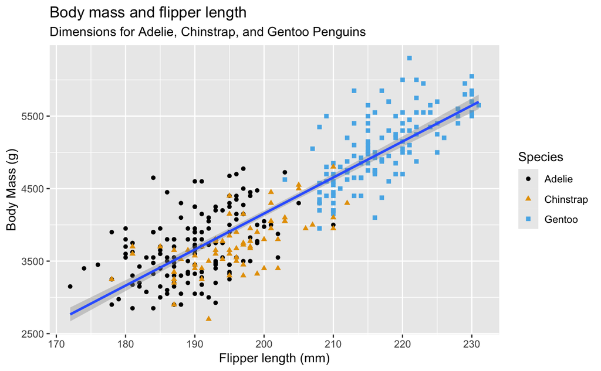

# Chapter 1 Penguins Exercises:

1. How many rows are in penguins? How many columns?

```
print(nrow(penguins))
```

```
[1] 344
```

```
print(ncol(penguins))
```

```
[1] 8
```

2. What does the bill_depth_mm variable in the penguins data frame describe? Read the help for ?penguins to find out.

lol.

3. Make a scatterplot of bill_depth_mm vs. bill_length_mm. That is, make a scatterplot with bill_depth_mm on the y-axis and bill_length_mm on the x-axis. Describe the relationship between these two variables.

```
ggplot(data = penguins,
       mapping = aes(x=bill_length_mm, y=bill_depth_mm, color = species)
       ) + geom_point() + geom_smooth(method = "glm")
```

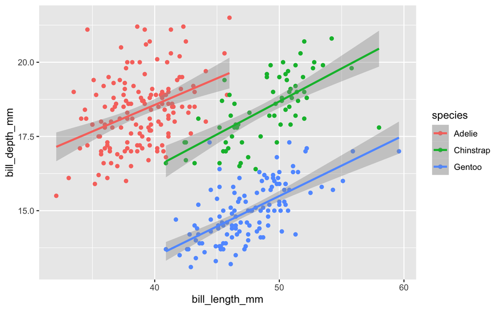

```
NA
```

There is a positive linear relationship, and there is clear differentiation between the different species.

4. What happens if you make a scatterplot of species vs. bill_depth_mm? What might be a better choice of geom?

[output not shown]

5. Why does the following give an error and how would you fix it?

```
ggplot(data = penguins) +
  geom_point()
```

You need to define the x and y axes, done as the “mapping” parameter in the main ggplot call.

6. What does the na.rm argument do in geom_point()? What is the default value of the argument? Create a scatterplot where you successfully use this argument set to TRUE.

[output not shown]

7. Add the following caption to the plot you made in the previous exercise: “Data come from the palmerpenguins package.” Hint: Take a look at the documentation for labs(). done
8. Recreate the following visualization. What aesthetic should bill_depth_mm be mapped to? And should it be mapped at the global level or at the geom level?

[output not shown]

9. Run the code in your head.

```
ggplot(
  data = penguins,
  mapping = aes(x = flipper_length_mm, y = body_mass_g, color = island)
) +
  geom_point() +
  geom_smooth(se = FALSE)
```

# Visualizing Distributions

## reordering bar graphs by frequency

[output not shown]

## creating a histogram

[output not shown]

## density curve

density curve continuous analog to histogram

[output not shown]

# Visualizing Distribution Exercises

1. Make a bar plot of species of penguins, where you assign species to the y aesthetic. How is this plot different?